# Impact of Severe Weather Events on the Population Health and Economy in US

Valentina Scipione

23 May 2015

## Synopsis

Storms and other severe weather events can cause both public health and economic problems for communities and municipalities. Many severe events can result in fatalities, injuries, and property damage, and preventing such outcomes to the extent possible is a key concern.

In this report we aim to analyse the impact of severe weather events in order to unveil which types of weather events are the most harmful with respect to population health and economy. We found out that the most damaging events for public health are tornadoes, whereas hurrycanes and typhoons are responsible for the most economic losses, mostly due to property damages.

## Loading and Processing the Raw Data

We explored the [U.S. National Oceanic and Atmospheric Administration’s (NOAA) storm database](https://d396qusza40orc.cloudfront.net/repdata%2Fdata%2FStormData.csv.bz2), which tracks characteristics of major storms and weather events in the United States from the year 1950 to November 2011.

```r
stormData <- read.csv(bzfile("./data/repdata-data-StormData.csv.bz2"))
```

## Analysis

In the first part of the analysis we investigated which types of events are most harmful with respect to population health.

```r
# Find death and injuries events
casualties <- aggregate(stormData[,c("FATALITIES","INJURIES")], by=list(stormData$EVTYPE), "sum")

# Top 10 weather events causing fatalities and injuries
top_fatalities <- head(casualties[order(casualties$FATALITIES, decreasing = T), ], 10)
top_injuries <- head(casualties[order(casualties$INJURIES, decreasing = T), ], 10)

top_casualties <- cbind(top_fatalities[,c("Group.1","FATALITIES")],
                        top_injuries[,c("Group.1","INJURIES")])
colnames(top_casualties) <- c("Weather Event Fatalities", "Fatalities", "Weather Event Injuries", "Injuries")
```

```r
options("scipen"=100, "digits"=0)
tot_fatalities <- sum(casualties$FATALITIES)
tot_injuries <- sum(casualties$INJURIES)

casualties_tornado <- stormData[stormData$EVTYPE == "TORNADO",c("INJURIES","FATALITIES")]
tot_fatalities_tornado <- sum(casualties_tornado$FATALITIES)
tot_injuries_tornado <- sum(casualties_tornado$INJURIES)

# Calculate percentages
percent_fatalities <- tot_fatalities_tornado / tot_fatalities * 100
percent_injuries <- tot_injuries_tornado / tot_injuries * 100
```

```r
# Make plot
library(ggplot2)
library(gridExtra)
graph_fatalities <- ggplot(data=top_fatalities,
             aes(x=reorder(Group.1, FATALITIES), y=FATALITIES, fill=FATALITIES)) +
    geom_bar(stat="identity") +
    coord_flip() +
    ylab("Total Fatalities") +
    xlab("Weather Event") +
    theme(legend.position="none")

graph_injuries <- ggplot(data=top_injuries,
             aes(x=reorder(Group.1, INJURIES), y=INJURIES, fill=INJURIES)) +
    geom_bar(stat="identity") +
    coord_flip() +
    ylab("Total Injuries") +
    xlab("Weather Event") +
    theme(legend.position="none")
```

In the second part of the analysis the types of events which have the greatest economic consequences were investigated.

```r
# Find property damage events
property_dmg <- stormData[,c("EVTYPE","PROPDMG","PROPDMGEXP","CROPDMG","CROPDMGEXP")]

# Convert letter into exponential value (H -> 10e2, K -> 10e3, M -> 10e6, B -> 10e9)
exp_transform <- function(x) {
        switch(toupper(x), "H" = 10E2, "K" = 10E3, "M" = 10E6, "B" = 10E9 , 1)
        }

property_dmg$propexp <- sapply(property_dmg$PROPDMGEXP, FUN=exp_transform)
property_dmg$cropexp <- sapply(property_dmg$CROPDMGEXP, FUN=exp_transform)

property_dmg$PROPDMGEXP <- as.numeric(property_dmg$PROPDMGEXP)
property_dmg$propdmg <- property_dmg$propexp * property_dmg$PROPDMGEXP

property_dmg$CROPDMGEXP <- as.numeric(property_dmg$CROPDMGEXP)
property_dmg$cropdmg <- property_dmg$cropexp * property_dmg$CROPDMGEXP

property_dmg$totdmg <- property_dmg$propdmg + property_dmg$cropdmg

economic_dmg <- aggregate(property_dmg[,c("propdmg","cropdmg", "totdmg")], by=list(property_dmg$EVTYPE), "sum")

# Top 10 weather events causing economic damage
top_propdmg <- head(economic_dmg[order(economic_dmg$propdmg, decreasing = T), ], 10)
top_cropdmg <- head(economic_dmg[order(economic_dmg$cropdmg, decreasing = T), ], 10)
top_totdmg <- head(economic_dmg[order(economic_dmg$totdmg,decreasing = T), ], 10)

top_economic <- cbind(top_propdmg[,c("Group.1","propdmg")],
                      top_cropdmg[,c("Group.1","cropdmg")],
                      top_totdmg[,c("Group.1","totdmg")])
colnames(top_economic) <- c("Weather Event Property","Property Damage","Weather Event Crop","Crop Damage", "Weather Event Total", "Total Damage")
```

```r
# Make plot
graph_prop <- ggplot(data=top_propdmg,
             aes(x=reorder(Group.1, propdmg), y=propdmg, fill=propdmg )) +
    geom_bar(stat="identity") +
    coord_flip() +
    xlab("Weather Event") +
    ylab("Property Damage ($)") +
    theme(legend.position="none")

graph_crop <- ggplot(data=top_cropdmg,
             aes(x=reorder(Group.1, cropdmg), y=cropdmg, fill=cropdmg)) +
    geom_bar(stat="identity") +
    coord_flip() +
    xlab("Weather Event") +
    ylab("Crop Damage ($)") +
    theme(legend.position="none")
```

```r
# Calculate percentage
tot_propdmg <- sum(property_dmg$totdmg)
tot_hurrycane <- sum(economic_dmg[economic_dmg$Group.1=="HURRICANE/TYPHOON",c("totdmg")])

percent_hurrycane <- tot_hurrycane / tot_propdmg * 100
```

## Results

Our analysis shows that tornados are by far the most harmful events to human health and are responsible for 37% of all fatalities and 65% of all injuries.

Below is a table of the top 10 weather events causing fatalities and injuries, respectively:

Table continues below

|  | Weather Event Fatalities | Fatalities |
| --- | --- | --- |
| **834** | TORNADO | 5633 |
| **130** | EXCESSIVE HEAT | 1903 |
| **153** | FLASH FLOOD | 978 |
| **275** | HEAT | 937 |
| **464** | LIGHTNING | 816 |
| **856** | TSTM WIND | 504 |
| **170** | FLOOD | 470 |
| **585** | RIP CURRENT | 368 |
| **359** | HIGH WIND | 248 |
| **19** | AVALANCHE | 224 |

|  | Weather Event Injuries | Injuries |
| --- | --- | --- |
| **834** | TORNADO | 91346 |
| **130** | TSTM WIND | 6957 |
| **153** | FLOOD | 6789 |
| **275** | EXCESSIVE HEAT | 6525 |
| **464** | LIGHTNING | 5230 |
| **856** | HEAT | 2100 |
| **170** | ICE STORM | 1975 |
| **585** | FLASH FLOOD | 1777 |
| **359** | THUNDERSTORM WIND | 1488 |
| **19** | HAIL | 1361 |

Here is the corresponding plot:

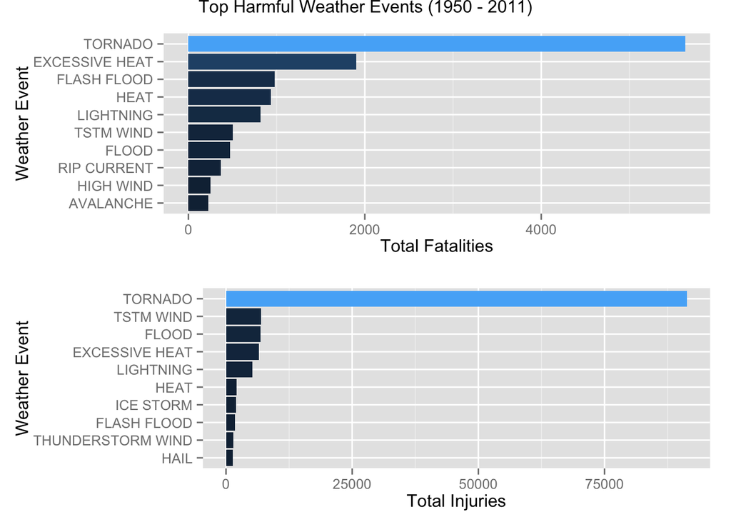

For what concerns the impact of weather events on the economy, hurrycanes and typhoons are responsible for the most economic losses and account for 21% of property damage.

Below is a table of the top 10 weather events causing property and crop damage, respectively:

Table continues below

|  | Weather Event Property | Property Damage |
| --- | --- | --- |
| **411** | HURRICANE/TYPHOON | 1688742040018 |
| **834** | TORNADO | 1278269338937 |
| **170** | FLOOD | 992636717936 |
| **402** | HURRICANE | 434637820048 |
| **153** | FLASH FLOOD | 432622951416 |
| **244** | HAIL | 320206872882 |
| **670** | STORM SURGE | 288002270086 |
| **408** | HURRICANE OPAL | 280560510001 |
| **359** | HIGH WIND | 199539576093 |
| **957** | WILDFIRE | 168051100784 |

Table continues below

|  | Weather Event Crop | Crop Damage | Weather Event Total |
| --- | --- | --- | --- |
| **411** | DROUGHT | 212876110971 | HURRICANE/TYPHOON |
| **834** | HAIL | 56571856362 | TORNADO |
| **170** | HURRICANE/TYPHOON | 51890770055 | FLOOD |
| **402** | FREEZE | 51080140059 | FLASH FLOOD |
| **153** | RIVER FLOOD | 50450980153 | HURRICANE |
| **244** | ICE STORM | 50426921045 | HAIL |
| **670** | HEAT | 50313890136 | STORM SURGE |
| **408** | FLOOD | 32429051704 | HURRICANE OPAL |
| **359** | FLASH FLOOD | 17794892598 | DROUGHT |
| **957** | TSTM WIND | 13232273340 | HIGH WIND |

|  | Total Damage |
| --- | --- |
| **411** | 1740632810073 |
| **834** | 1286674880004 |
| **170** | 1025065769640 |
| **402** | 450417844014 |
| **153** | 438060060152 |
| **244** | 376778729244 |
| **670** | 288002760340 |
| **408** | 280820510007 |
| **359** | 218620372052 |
| **957** | 204571364804 |

Here is the corresponding plot:

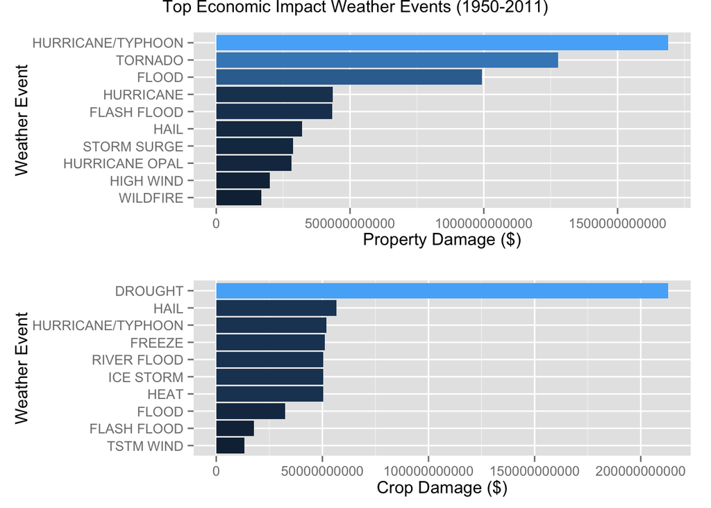